# GEL - Age of clinically classified variants

Sam Tallman

10 October, 2025

# 1 Packages

```r
library(tidyverse)
library(data.table)
library(viridis)
library(cowplot)
library(ggpubr)
library(reticulate)
library(zoo)
library(rtracklayer)
library(grid)
library(magrittr)
library(glue)
library(tidypolars)
library(polars)

## virtual env in container
use_virtualenv("/opt/python_env", required = TRUE)
```

# 2 Functions

```r
## Python functions for reticulate
source_python("functions/gel-funcs.py")

## Source R functions
source("functions/gel-funcs.R")
source("functions/gel-plotting_funcs.R")
```

# 3 Parameters

File paths from config…

```r
config <- yaml::read_yaml("config/config.yaml")

# Fill templates
paths <- lapply(config$paths, function(path) {
  if (grepl("\\{chrom\\}|\\{chrom_no_prefix\\}", path)) {
    return(NULL)   # skip chrom-templated paths
  }
  glue(path,
       data_dir       = config$paths$data_dir,
       singletons_dir = config$paths$singletons_dir
  )
})

paths <- Filter(Negate(is.null), paths)
```

# 4 Data Ingest

```r
## List of trees (with singletons included)
ts_tsv = params$ts_tsv
trees_list <- read_tsv(ts_tsv)
ts_dir <- paths$ts_dir
```

```r
pops_df <- read_tsv(paths$pops_path) %>%
mutate(pop = ifelse(pop %in% c("fin", "oth"), "remaining", pop))

hapmap_rates_list <- list()
for (chrom in unique(trees_list$chromosome)) {
  hapmap_rates_list[[chrom]] <- read_tsv(
    paste0("/public_data_resources/recomb_hg38/genetic_map_GRCh38_", chrom, ".txt")
  )
}

hapmap_rates <- do.call(rbind, hapmap_rates_list) %>%
dplyr::rename(chromosome = chrom) %>%
as_tibble()

clinvar_snvs <- read_tsv(paths$clinvar_tsv) %>%
  mutate(varkey = paste0(chromosome, "-", position))
```

Ploting data / parameters

```r
region_length <- 100000

ensembl_transcripts <- readGFF(paths$genes_ensembl) %>%
  mutate(chromosome = paste0("chr", seqid))

pop_colours_vec <- c(
  "#CC79A7", "#F0E442", "#0072B2", "#D55E00", "grey80", "#009E73", "#E69F00", "#56B4E9"
)

remain_collapse <- c("fin", "oth")
group_numbers <- pops_df %>%
count(pop) %>%
arrange(n) %>%
mutate(
  pop = factor(pop, levels = pop),
  Dataset = "GEL",
  colour = pop_colours_vec
)
```

## 4.1 Read in data from all chromosome ts_dfs

Columns used in the analyses…

```r
selected_columns <- c(
    "chromosome",
    "position",
    "AC_ts",
    "AF_ts",
    "pop",
    "panel_app_moi",
    "cpg_transition",
    "denovo_mutation",
    "AM_score",
    "AF_gnomad_exomes",
    "AF_gnomad_genomes",
    "mutation_root_parent",
    "mean_time",
    "ts_name",
    "rsid",
    "gene_symbol",
    "consequence",
    "lower_conf_time",
    "upper_conf_time",
    "acmg_classification_broad"
  )
```

Lazy loading for filtering etc.

```r
ts_lf_merge <- scan_parquet_polars(file.path(paths$output_dir, "all-chr*-df.parquet")) |>
  dplyr::select(all_of(selected_columns)) |>
  compute() |>
  filter(
    mutation_root_parent == FALSE & !is.na(mean_time)
  )
```

# 5 Analysis

## 5.1 Subset to clinically classified set

Clinically classified mutation set - Ultra-rare AF < 0.1% - ACMG classification broad (GEL or Clinvar is B/LB, VUS, or P/LP) - Non-synonymous consequence types - Not deNovo mutations - Within PanelApp clinical grade disease genes

```r
checkpoint_clinical_tsv <- paste0(
  paths$output_dir, "checkpoints/clinical_variants_ages-analysis.tsv.gz"
)

if (file.exists(checkpoint_clinical_tsv)) {
  candidate_vars_df <- fread(
    checkpoint_clinical_tsv
  )
} else {
  candidate_vars_df <- ts_lf_merge %>%
    filter(acmg_classification_broad %in% c("B/LB", "VUS", "P/LP")) %>%
    drop_na(consequence) %>%
    as_tibble() %>%
    filter(
      !panel_app_moi %in% c("Unknown", "BOTH") &
      grepl("missense|start_lost|stop_lost|stop_gain|splice_acceptor|splice_donor", consequence) &
      AC_ts <= max_ac_count(ts_df_merge, AF_thresh = 0.001)
    )
  candidate_vars_df %>%
    fwrite(
      checkpoint_clinical_tsv,
      sep = "\t", row.names = FALSE
    )
}
```

How many variants in total in the set?

```r
candidate_vars_df %<>%
  filter(
    !panel_app_moi %in% c("Unknown", "BOTH"),
    mutation_root_parent == FALSE & !is.na(mean_time)
  ) %>%
  mutate(varkey = paste0(chromosome, "-", position))
nrow(candidate_vars_df)
```

```
## [1] 20162
```

Count by ACMG/AMP classification

```r
candidate_vars_df %>%
  count(acmg_classification_broad)
```

```
##    acmg_classification_broad     n
##                       <char> <int>
## 1:                      B/LB  2507
## 2:                      P/LP  1302
## 3:                       VUS 16353
```

## 5.2 Clinically classified singletons

How many are singletons?

```r
candidate_vars_df_singletons <- candidate_vars_df %>%
  filter(AC_ts == 1)
nrow(candidate_vars_df_singletons)
```

```
## [1] 7464
```

Singletons by clinical classifcaition…

```r
singletons_acmg<- candidate_vars_df_singletons %>%
filter(AC_ts == 1) %>%
group_by(acmg_classification_broad) %>%
summarise(
  n_total = n(),
  n_under_100 = mean(mean_time < 100),
  gmean_time = exp(mean(log(mean_time)))
)

knitr::kable(singletons_acmg)
```

| acmg_classification_broad | n_total | n_under_100 | gmean_time |
| --- | --- | --- | --- |
| B/LB | 380 | 0.7447368 | 60.31734 |
| P/LP | 749 | 0.8638184 | 44.16154 |
| VUS | 6335 | 0.7853197 | 54.58210 |

### 5.2.1 Clinically classified singletons perm test

Are these age distributions statistically different?

```r
patho_ac1_set <- candidate_vars_df_singletons  %>%
filter(AC_ts == 1 & acmg_classification_broad == "P/LP")
benign_ac1_set <- candidate_vars_df_singletons  %>%
filter(AC_ts == 1 & acmg_classification_broad == "B/LB")
vus_ac1_set <- candidate_vars_df_singletons %>%
filter(AC_ts == 1 & acmg_classification_broad == "VUS")
```

Patho vs benign permutation test… - Are patho younger than benign?

```r
perm_test(patho_ac1_set, benign_ac1_set)
```

```
## [1] 44.16154
## [1] 60.31734
```

```
## [1] 0
```

Patho vs benign permutation test… - Are patho younger than VUS?

```r
perm_test(patho_ac1_set, vus_ac1_set)
```

```
## [1] 44.16154
## [1] 54.5821
```

```
## [1] 0
```

How about the different sources of clinical classifications?

```r
patho_ac1_cva_set <- candidate_vars_df_singletons  %>%
filter(AC_ts == 1 & acmg_classification_broad == "P/LP" & !varkey %in% clinvar_snvs$varkey)
nrow(patho_ac1_cva_set)
```

```
## [1] 72
```

```r
patho_ac1_clinvar_set <- candidate_vars_df_singletons  %>%
filter(AC_ts == 1 & acmg_classification_broad == "P/LP" & varkey %in% clinvar_snvs$varkey)
nrow(patho_ac1_clinvar_set)
```

```
## [1] 677
```

```r
perm_test(patho_ac1_cva_set, patho_ac1_clinvar_set)
```

```
## [1] 32.67856
## [1] 45.59876
```

```
## [1] 0.006
```

DAC > 1 clinical variants

```r
candidate_vars_df_non_singletons <- candidate_vars_df %>%
filter(AC_ts != 1)
nrow(candidate_vars_df_non_singletons)
```

```
## [1] 12698
```

Across the ACMG/AMP classifications

```r
candidate_vars_df_non_singletons %>%
group_by(acmg_classification_broad) %>%
summarise(
  number = n(),
  geo_mean_time = exp(mean(log(mean_time)))
)
```

```
## # A tibble: 3 × 3
##   acmg_classification_broad number geo_mean_time
##   <chr>                      <int>         <dbl>
## 1 B/LB                        2127          245.
## 2 P/LP                         553          112.
## 3 VUS                        10018          132.
```

## 5.3 Clinically classified DAC>1 variants (recurrence check)

### 5.3.1 Calculcate IBD spans

NOTE: My functions are quite inefficient and slow. running this from scratch could take many hours! make sure to checkpoint…

We want to ensure that some of the variants are unlikely to be recurrents - As this will affect age estimates / make things unreliable.

```r
## All trees
ibd_df_list <- list()
ts_names_vec <- unique(candidate_vars_df_non_singletons$ts_name)
for (index in 1:length(ts_names_vec)) {
  tree <- trees_list %>%
    filter(grepl(ts_names_vec[index], ts_prefix))
  ibd_file <- paste0(
    paths$output_dir,
    "checkpoints/all-",
    ts_names_vec[index],
    "-carriers_mrca_span-clinical.tsv.gz"
  )
  if (file.exists(ibd_file)) {
    print(tree$chromosome)
    ibd_df_list[[index]] <- read_tsv(ibd_file) %>%
      mutate(chromosome = tree$chromosome)
  } else {
    var_df <- candidate_vars_df_non_singletons %>%
      filter(ts_name == ts_names_vec[index])
    ibd_df <- mrca_span_carriers(
      ts_path = paste0(ts_dir, tree$ts_prefix, ".trees.tsz"),
      positions = var_df$position
    ) %>%
      mutate(chromosome = tree$chromosome)
    ibd_df %>%
      fwrite(
        file.path(ibd_file), sep = "\t"
      )
  }
}
```

```
## [1] "chr16"
```

```
## [1] "chr16"
```

```
## [1] "chr17"
```

```
## [1] "chr17"
```

```
## [1] "chr17"
```

```
## [1] "chr17"
```

```
## [1] "chr17"
```

```
## [1] "chr18"
```

```
## [1] "chr19"
```

```
## [1] "chr20"
```

```
## [1] "chr20"
```

```
## [1] "chr21"
```

```
## [1] "chr21"
```

```
## [1] "chr22"
```

```
## [1] "chr22"
```

Generate the IBD data frame - stitch nearby segments together broken by small recombination events… - cM size from HapMap

```r
ibd_candidates_df <- do.call(rbind, ibd_df_list) %>%
  stitch_ibd_segments_by_position() %>%
  interpolate_cm(
    recomb_map = hapmap_rates,
    left = "ibd_left",
    right = "ibd_right"
  ) %>%
  calculate_ibd_age() %>%
  left_join(candidate_vars_df_non_singletons) %>%
  filter(
    position >= ibd_left & position <= ibd_right
  )
```

### 5.3.2 Calculcate edge spans

```r
edge_span_list <- list()
ts_names_vec <- unique(candidate_vars_df$ts_name)

for (index in 1:length(ts_names_vec)) {
  tree <- trees_list %>%
    filter(grepl(ts_names_vec[index], ts_prefix))
  edge_file <- paste0(
    paths$output_dir,
    "checkpoints/all-",
    ts_names_vec[index],
    "-candidates_edge_spans-clinical.tsv.gz"
  )
  if (file.exists(edge_file )) {
    print(tree$chromosome)
    edge_span_list[[index]] <- read_tsv(edge_file) %>%
      mutate(chromosome = tree$chromosome)
  } else {
    var_df <- candidate_vars_df %>%
      filter(ts_name == ts_names_vec[index])
    edge_df  <- edge_span_mutations(
      ts_path = paste0(ts_dir, tree$ts_prefix, ".trees.tsz"),
      positions = var_df$position
    ) %>%
      mutate(chromosome = tree$chromosome)
    edge_df %>%
      fwrite(
        file.path(edge_file), sep = "\t"
      )
     edge_span_list[[index]] <- edge_df
  }
}
```

```
## [1] "chr16"
```

```
## [1] "chr16"
```

```
## [1] "chr17"
```

```
## [1] "chr17"
```

```
## [1] "chr17"
```

```
## [1] "chr17"
```

```
## [1] "chr17"
```

```
## [1] "chr18"
```

```
## [1] "chr19"
```

```
## [1] "chr20"
```

```
## [1] "chr20"
```

```
## [1] "chr21"
```

```
## [1] "chr21"
```

```
## [1] "chr22"
```

```
## [1] "chr22"
```

```r
edge_candidates_df <- do.call(rbind, edge_span_list) %>%
mutate(
  edge_span = edge_right - edge_left
)
```

### 5.3.3 Apply recurrent check

Rules: - Child node should not show extreme uncertainty in dating (Coefficient of Variaton < 1) - Mutation should not create a new edge in the tree sequence - The edge should be consistent with the neighbouring genealogy (< span of IBD between all carriers at that site)

NOTE: Here IBD is defined as the span of the haplotype across which all carriers share the same MRCA

We can get the complete edge spans for all mutations to check this.

```r
annot_df <- candidate_vars_df_non_singletons %>%
left_join(ibd_candidates_df) %>%
mutate(
  within_ibd_span = ifelse(
    (position <= ibd_right & position >= ibd_left), TRUE, FALSE
)) %>%
filter(within_ibd_span) %>%
left_join(edge_candidates_df) %>%
mutate(
  edge_within_ibd_span = ifelse(
    (ibd_right < edge_right & edge_left > ibd_left),
    TRUE, FALSE
  )
) %>%
mutate(
  mutation_creates_edge = ifelse(
    (edge_left == position | edge_right == position),
    TRUE, FALSE
  ),
  mutation_creates_ibd = ifelse(
    (ibd_left == position | ibd_right == position),
    TRUE, FALSE
  ),
  child_cv  = ifelse(child_node_mean_time  > 0 & child_node_var_time  > 0,
                       sqrt(child_node_var_time)  / child_node_mean_time,  NA_real_),
  parent_cv = ifelse(parent_node_mean_time > 0 & parent_node_var_time > 0,
                       sqrt(parent_node_var_time) / parent_node_mean_time, NA_real_),
  poor_child_node = child_cv > 1,
  poor_parent_node = parent_cv > 1,
  ibd_smaller_than_edge = span <= edge_span
) %>%
mutate(
  recurrent_check = case_when(
    poor_child_node == TRUE ~ "Large uncertainty in child node time (CV > 1)",
    poor_child_node == FALSE & mutation_creates_edge == TRUE ~ "Mutation position is edge boundary",
    poor_child_node == FALSE & mutation_creates_edge == FALSE & ibd_smaller_than_edge == TRUE ~ "Shared IBD span <= edge span",
    TRUE ~ "Consistent with single origin"
  ),
  recurrent_check = factor(
    recurrent_check, levels = c(
      "Large uncertainty in child node time (CV > 1)",
      "Mutation position is edge boundary",
      "Shared IBD span <= edge span",
      "Consistent with single origin"
    )
  ),
  recurrent_unlikely = recurrent_check == "Consistent with single origin"
)
```

Recurrence by CpG>TPG transition Supplementary Plot

```r
custom_palette <- c("black", "darkred", "#FF6F61", "#69B3E7")
plot_top <- annot_df %>%
  mutate(
    AC_ts_trunc = ifelse(AC_ts > 9, ">9", as.character(AC_ts)),
    AC_ts_trunc = factor(AC_ts_trunc, levels = c(as.character(1:9), ">9"))
  ) %>%
  group_by(AC_ts_trunc, recurrent_check, cpg_transition) %>%
  tally() %>%
  group_by(cpg_transition, AC_ts_trunc) %>%
  mutate(
    prop = n / sum(n),
    cpg_transition = ifelse(cpg_transition, "CpG>TpG Transition", "Other mutation types")
  ) %>%
  ggplot(aes(x = factor(AC_ts_trunc), y = n, colour = recurrent_check, fill = recurrent_check)) +
  geom_bar(stat = "identity") +
  theme_classic(base_size = 20) +
  theme(
    strip.background = element_blank(),
    legend.position = "top",
    legend.title = element_blank(),  # Removes the legend title
    legend.text = element_text(size = 15),  # Adjust legend text size
    legend.key.size = unit(0.8, "cm"),  # Adjust legend key size
    axis.line.x = element_blank()
  ) +
  facet_wrap(~cpg_transition) +
  labs(
    x = "Derived Allele Count (DAC)",
    y = "Number of alleles"
  ) +
  scale_fill_manual(values = custom_palette) +
  scale_colour_manual(values = custom_palette) +
  guides(
    colour = guide_legend(ncol = 2),  # Set legend to 2 columns
    fill = guide_legend(ncol = 2)    # Set legend to 2 columns
  )

plot_bottom <- annot_df %>%
mutate(cpg_transition = ifelse(cpg_transition, "CpG>TpG Transition", "Other mutation types")) %>%
ggplot(aes(
  x = log10(mean_time), y = log10(cM_length),
  colour = recurrent_check, group = cpg_transition
)) +
geom_point(shape = 21, size = 0.75, alpha = 0.5) +
theme_bw(base_size = 20) +
theme(
  strip.background = element_blank(),
  panel.grid = element_blank(),
  legend.position = "none"
) +
#geom_errorbar(
#    aes(
#      xmin = log10(child_node_mean_time),
#      xmax = log10(parent_node_mean_time)
#    ), alpha = 0.1
#  ) +
facet_wrap(~cpg_transition) +
labs(
  colour = "",
  x = "Allele age (generations)",
  y = "IBD length (cM)"
) +
scale_x_continuous(expand = c(0, 0), labels = scales::math_format(10^.x)) +
scale_y_continuous(expand = c(0, 0), labels = scales::math_format(10^.x)) +
    annotation_logticks(
      sides = "bl",
      color = "grey40"
) +
guides(
  colour = guide_legend(ncol = 1),  # Set legend to 2 columns
) +
scale_colour_manual(values = custom_palette) +
geom_smooth(method = "lm", colour = "black", se = FALSE, linetype = "dashed")
```

Combine plot

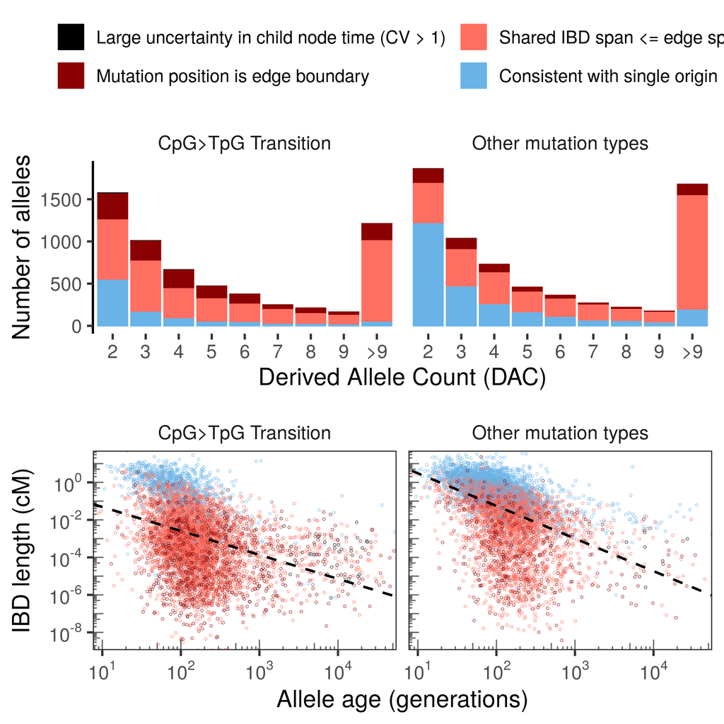

```r
## Arrange bottom plot
recurrent_supp_plot <- ggarrange(
  plot_top,
  plot_bottom,
  ncol = 1,
  align = "v",
  heights = c(1, 0.8)
)
recurrent_supp_plot
```

Save plot

```r
ggsave(paste0(paths$plots_dir, "supp_plot_recurr.pdf"), recurrent_supp_plot, width = 9, height = 10.5)
```

Tabulate recurrence of doubletons

```r
recurr_doubletons_by_cpg <- annot_df %>%
  filter(AC_ts == 2) %>%
  group_by(recurrent_unlikely, cpg_transition) %>%
  tally() %>%
  group_by(cpg_transition) %>%
  mutate(prop = n / sum(n)) %>%
  arrange(desc(cpg_transition))
knitr::kable(recurr_doubletons_by_cpg, bookends = FALSE)
```

| recurrent_unlikely | cpg_transition | n | prop |
| --- | --- | --- | --- |
| FALSE | TRUE | 1035 | 0.6575604 |
| TRUE | TRUE | 539 | 0.3424396 |
| FALSE | FALSE | 651 | 0.3500000 |
| TRUE | FALSE | 1209 | 0.6500000 |

## 5.4 Clinically classified doubletons (non-recurrent)

Not recurrent doubletons by clinical classifcaition…

```r
nonrecurrent_doubletons_acmg<- annot_df %>%
filter(
  recurrent_unlikely
) %>%
filter(AC_ts == 2) %>%
group_by(acmg_classification_broad) %>%
summarise(
  n_total = n(),
  mean_length = mean(cM_length),
  iqr_length = sd(cM_length),
  n_under_100 = mean(mean_time < 100),
  mean_child = mean(child_node_mean_time),
  iqr_child = sd(child_node_mean_time),
  gmean_time = exp(mean(log(mean_time)))
)

knitr::kable(nonrecurrent_doubletons_acmg)
```

| acmg_classification_broad | n_total | mean_length | iqr_length | n_under_100 | mean_child | iqr_child | gmean_time |
| --- | --- | --- | --- | --- | --- | --- | --- |
| B/LB | 129 | 1.475817 | 2.039468 | 0.6666667 | 39.08545 | 132.19153 | 81.05049 |
| P/LP | 107 | 4.495714 | 5.034760 | 0.8130841 | 17.25608 | 21.47993 | 55.40357 |
| VUS | 1512 | 2.419284 | 3.892418 | 0.6660053 | 28.33434 | 80.91790 | 75.58812 |

### 5.4.1 Clinically classified doubletons perm test

Are these age distributions statistically different?

```r
patho_ac2_set <- annot_df %>%
filter(recurrent_unlikely & AC_ts == 2 & acmg_classification_broad == "P/LP")
benign_ac2_set <- annot_df %>%
filter(recurrent_unlikely & AC_ts == 2 & acmg_classification_broad == "B/LB")
vus_ac2_set <- annot_df %>%
filter(recurrent_unlikely & AC_ts == 2 & acmg_classification_broad == "VUS")
```

Patho vs benign permutation test… - Are patho younger than benign?

```r
perm_test(patho_ac2_set, benign_ac2_set)
```

```
## [1] 55.40357
## [1] 81.05049
```

```
## [1] 0.0018
```

Patho vs benign permutation test… - Are patho younger than VUS?

```r
perm_test(patho_ac2_set, vus_ac2_set)
```

```
## [1] 55.40357
## [1] 75.58812
```

```
## [1] 0.004
```

### 5.4.2 Allele age extremes by pop / clinically classifcation

Allele age extremes for doubletons per pop Restrict to largest groups…

- B/LB

```r
blb_pop <- annot_df %>%
  filter(acmg_classification_broad == "B/LB" & AC_ts == 2) %>%
  filter(recurrent_unlikely & pop %in% c("afr", "nfe", "eas", "sas")) %>%
  group_by(pop, AC_ts) %>%
  summarise(
    n_variants = n(),
    max_time = max(mean_time),
    min_time = min(mean_time),
    gmean_time = exp(mean(log(mean_time)))
  ) %>%
  filter(n_variants > 1)
knitr::kable(blb_pop, bookends = FALSE)
```

| pop | AC_ts | n_variants | max_time | min_time | gmean_time |
| --- | --- | --- | --- | --- | --- |
| afr | 2 | 13 | 627.4293 | 35.13713 | 123.49853 |
| eas | 2 | 13 | 506.0545 | 33.55614 | 98.07036 |
| nfe | 2 | 52 | 481.2816 | 13.29154 | 54.10338 |
| sas | 2 | 13 | 138.9581 | 29.01580 | 79.27521 |

- VUS

```r
vus_pop <- annot_df %>%
  filter(acmg_classification_broad == "VUS"  & AC_ts == 2) %>%
  filter(recurrent_unlikely & pop %in% c("afr", "nfe", "eas", "sas")) %>%
  group_by(pop, AC_ts) %>%
  summarise(
    n_variants = n(),
    max_time = max(mean_time),
    min_time = min(mean_time),
    gmean_time = exp(mean(log(mean_time)))
  ) %>%
  filter(n_variants > 1)
knitr::kable(vus_pop, bookends = FALSE)
```

| pop | AC_ts | n_variants | max_time | min_time | gmean_time |
| --- | --- | --- | --- | --- | --- |
| afr | 2 | 119 | 35340.038 | 18.578060 | 136.35967 |
| eas | 2 | 23 | 21657.055 | 30.519351 | 122.06330 |
| nfe | 2 | 959 | 9465.179 | 7.590653 | 63.25537 |
| sas | 2 | 150 | 1050.866 | 10.767209 | 70.97121 |

- P/LP

```r
plp_pop <- annot_df %>%
  filter(acmg_classification_broad == "P/LP" & AC_ts == 2) %>%
  filter(recurrent_unlikely & pop %in% c("afr", "nfe", "eas", "sas")) %>%
  group_by(pop, AC_ts) %>%
  summarise(
    n_variants = n(),
    max_time = max(mean_time),
    min_time = min(mean_time),
    gmean_time = exp(mean(log(mean_time)))
  ) %>%
  filter(n_variants > 1)
knitr::kable(plp_pop, bookends = FALSE)
```

| pop | AC_ts | n_variants | max_time | min_time | gmean_time |
| --- | --- | --- | --- | --- | --- |
| nfe | 2 | 83 | 339.0935 | 10.36707 | 54.72426 |
| sas | 2 | 13 | 163.2588 | 18.89343 | 45.26764 |

Supplemental plot - We want to show differences in ages despite population AC (2) matches.

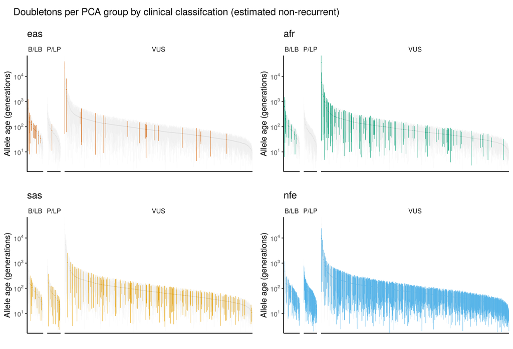

```r
pop_vec <- c(as.character(group_numbers$pop), "nonspecific")
pop_colours_vec = c(pop_colours_vec, "grey50")
pop_cols <- stats::setNames(pop_colours_vec, pop_vec)

pop_vec_reduced <- which(pop_vec %in% c("afr", "nfe", "eas", "sas"))
plot_list <- setNames(lapply(pop_vec, plot_one_pop_classify), pop_vec)
p_core  <- plot_grid(plotlist = plot_list[pop_vec_reduced])
title_g <- ggdraw() +
  draw_label("     Doubletons per PCA group by clinical classifcation (estimated non-recurrent)", x = 0, hjust = 0,
             size = 30) +
  theme(plot.margin = margin(0, 0, 8, 0))
p_grid <- plot_grid(title_g, p_core, ncol = 1, rel_heights = c(0.08, 1))
p_grid
```

Save to PDf

```r
ggsave(paste0(paths$plots_dir, "test_age_by_pop_doubletons.pdf"), p_grid, width = 22, height = 15)
```

Tabulate pathogenic variants - P/LP

```r
total_path <- annot_df %>%
  filter(
    pop %in% c("afr", "nfe", "eas", "sas") & AC_ts == 2 &
    recurrent_unlikely & acmg_classification_broad == "P/LP"
  ) %>%
  dplyr::select(
  chromosome, acmg_classification_broad, AC_ts, panel_app_moi, position, gene_symbol, consequence, mean_time, upper_conf_time, lower_conf_time, pop
)
knitr::kable(total_path, bookends = FALSE)
```

| chromosome | acmg_classification_broad | AC_ts | panel_app_moi | position | gene_symbol | consequence | mean_time | upper_conf_time | lower_conf_time | pop |
| --- | --- | --- | --- | --- | --- | --- | --- | --- | --- | --- |
| chr16 | P/LP | 2 | BIALLELIC | 551394 | CAPN15 | missense_variant | 52.55831 | 120.16345 | 12.708436 | nfe |
| chr16 | P/LP | 2 | BIALLELIC | 1985985 | GFER | missense_variant | 47.77250 | 113.45879 | 10.294645 | nfe |
| chr16 | P/LP | 2 | BIALLELIC | 2043727 | NTHL1 | splice_acceptor_variant | 62.17167 | 128.30368 | 19.817571 | nfe |
| chr16 | P/LP | 2 | BIALLELIC | 2285584 | ABCA3 | missense_variant | 25.16607 | 54.28278 | 7.159785 | nfe |
| chr16 | P/LP | 2 | BIALLELIC | 3026677 | THOC6 | splice_acceptor_variant | 40.09213 | 93.94279 | 9.007046 | nfe |
| chr16 | P/LP | 2 | BIALLELIC | 3584767 | SLX4 | splice_donor_variant | 121.58904 | 327.67073 | 16.836300 | nfe |
| chr16 | P/LP | 2 | BIALLELIC | 8804844 | PMM2 | splice_donor_variant | 198.30357 | 398.36940 | 67.486661 | nfe |
| chr16 | P/LP | 2 | BIALLELIC | 8811674 | PMM2 | missense_variant | 63.23282 | 135.65637 | 18.249704 | nfe |
| chr16 | P/LP | 2 | BIALLELIC | 8813028 | PMM2 | stop_gained | 129.18582 | 270.41176 | 39.737126 | nfe |
| chr16 | P/LP | 2 | BIALLELIC | 8813087 | PMM2 | missense_variant | 55.57409 | 105.28473 | 21.616439 | nfe |
| chr16 | P/LP | 2 | BIALLELIC | 13930789 | ERCC4 | stop_gained | 86.56462 | 184.75525 | 25.324829 | nfe |
| chr17 | P/LP | 2 | MONOALLELIC | 1650818 | PRPF8 | missense_variant | 43.57708 | 100.58793 | 10.243104 | nfe |
| chr17 | P/LP | 2 | BIALLELIC | 5433416 | C1QBP | splice_acceptor_variant | 55.11005 | 129.87059 | 12.166255 | nfe |
| chr17 | P/LP | 2 | BIALLELIC | 7222842 | ACADVL | missense_variant | 117.18889 | 267.11745 | 28.587801 | nfe |
| chr17 | P/LP | 2 | BIALLELIC | 8231749 | CTC1 | stop_gained | 143.20563 | 307.32570 | 41.295296 | nfe |
| chr17 | P/LP | 2 | BIALLELIC | 11875146 | DNAH9 | stop_gained | 109.71689 | 242.64310 | 29.166012 | nfe |
| chr17 | P/LP | 2 | BIALLELIC | 18125217 | MYO15A | missense_variant | 77.50723 | 178.64587 | 18.298251 | nfe |
| chr17 | P/LP | 2 | BIALLELIC | 18158522 | MYO15A | splice_acceptor_variant | 113.03240 | 264.54815 | 25.483519 | nfe |
| chr17 | P/LP | 2 | BIALLELIC | 37179370 | ACACA | missense_variant | 64.86133 | 132.51938 | 21.191812 | nfe |
| chr17 | P/LP | 2 | MONOALLELIC | 37701013 | HNF1B | missense_variant | 71.07118 | 131.70978 | 28.982405 | nfe |
| chr17 | P/LP | 2 | BIALLELIC | 39673513 | PGAP3 | splice_donor_variant | 74.62511 | 147.73015 | 26.289170 | nfe |
| chr17 | P/LP | 2 | BIALLELIC | 42911236 | G6PC1 | missense_variant | 28.51135 | 60.56849 | 8.443310 | nfe |
| chr17 | P/LP | 2 | BIALLELIC | 47946670 | PNPO | missense_variant | 86.74342 | 189.97096 | 23.687314 | nfe |
| chr17 | P/LP | 2 | MONOALLELIC | 49619049 | SPOP | missense_variant | 208.67186 | 476.00001 | 50.792959 | nfe |
| chr17 | P/LP | 2 | BIALLELIC | 50166042 | SGCA | start_lost | 26.03629 | 59.19033 | 6.400314 | sas |
| chr17 | P/LP | 2 | BIALLELIC | 50169120 | SGCA | missense_variant | 17.87402 | 40.75420 | 4.356373 | nfe |
| chr17 | P/LP | 2 | MONOALLELIC | 50190578 | COL1A1 | missense_variant | 211.15573 | 516.81376 | 41.315420 | nfe |
| chr17 | P/LP | 2 | MONOALLELIC | 50197235 | COL1A1 | splice_acceptor_variant | 50.23668 | 102.43255 | 16.494623 | sas |
| chr17 | P/LP | 2 | MONOALLELIC | 50198432 | COL1A1 | splice_donor_variant | 41.22627 | 88.00766 | 12.054360 | nfe |
| chr17 | P/LP | 2 | BIALLELIC | 58216087 | MKS1 | splice_donor_variant | 24.66995 | 58.35302 | 5.383919 | nfe |

[output cut: 67 more lines]

Tabulate only very old VUS? - VUS

```r
super_old_vus <- annot_df %>%
  filter(
    pop %in% c("afr", "nfe", "eas", "sas") & AC_ts == 2 &
    recurrent_unlikely & acmg_classification_broad == "VUS" &
    mean_time > (max(total_path$mean_time) * 10)
  ) %>%
  dplyr::select(
  chromosome, position, rsid, acmg_classification_broad, AC_ts, panel_app_moi, position, gene_symbol, consequence, mean_time, upper_conf_time, lower_conf_time, pop
  ) %>%
  arrange(desc(mean_time))
nrow(super_old_vus)
```

```
## [1] 6
```

```r
knitr::kable(super_old_vus, bookends = FALSE)
```

| chromosome | position | rsid | acmg_classification_broad | AC_ts | panel_app_moi | gene_symbol | consequence | mean_time | upper_conf_time | lower_conf_time | pop |
| --- | --- | --- | --- | --- | --- | --- | --- | --- | --- | --- | --- |
| chr21 | 44525821 | rs139112987 | VUS | 2 | BIALLELIC | TSPEAR | missense_variant | 35340.038 | 89540.94 | 6148.7184 | afr |
| chr22 | 20090255 | rs777348779&COSV61225947 | VUS | 2 | MONOALLELIC | DGCR8 | missense_variant | 21657.055 | 58215.40 | 3028.7692 | eas |
| chr16 | 580192 | rs1361495767 | VUS | 2 | BIALLELIC | PIGQ | missense_variant | 9465.179 | 29109.74 | 728.1554 | nfe |
| chr17 | 75842559 | rs551855408 | VUS | 2 | BIALLELIC | UNC13D | missense_variant | 5596.329 | 16503.37 | 527.6172 | afr |
| chr19 | 5110736 | rs1466512977 | VUS | 2 | MONOALLELIC | KDM4B | missense_variant | 5369.485 | 17197.42 | 333.7404 | nfe |
| chr17 | 77488314 | rs762543093 | VUS | 2 | MONOALLELIC | SEPTIN9 | missense_variant | 4827.751 | 10903.15 | 1209.5850 | nfe |

Lets pick an interesting doubleton as plotting examples…

```r
examples_vus <- super_old_vus %>%
  filter(AC_ts == 2 & pop != "nonspecific")
examples_vus
```

```
##    chromosome position                     rsid acmg_classification_broad AC_ts
##        <char>    <num>                   <char>                    <char> <int>
## 1:      chr21 44525821              rs139112987                       VUS     2
## 2:      chr22 20090255 rs777348779&COSV61225947                       VUS     2
## 3:      chr16   580192             rs1361495767                       VUS     2
## 4:      chr17 75842559              rs551855408                       VUS     2
## 5:      chr19  5110736             rs1466512977                       VUS     2
## 6:      chr17 77488314              rs762543093                       VUS     2
##    panel_app_moi gene_symbol      consequence mean_time upper_conf_time
##           <char>      <char>           <char>     <num>           <num>
## 1:     BIALLELIC      TSPEAR missense_variant 35340.038        89540.94
## 2:   MONOALLELIC       DGCR8 missense_variant 21657.055        58215.40
## 3:     BIALLELIC        PIGQ missense_variant  9465.179        29109.74
## 4:     BIALLELIC      UNC13D missense_variant  5596.329        16503.37
## 5:   MONOALLELIC       KDM4B missense_variant  5369.485        17197.42
## 6:   MONOALLELIC     SEPTIN9 missense_variant  4827.751        10903.15
##    lower_conf_time    pop
##              <num> <char>
## 1:       6148.7184    afr
## 2:       3028.7692    eas
## 3:        728.1554    nfe
## 4:        527.6172    afr
## 5:        333.7404    nfe
## 6:       1209.5850    nfe
```

### 5.4.3 Extreme age example (DGCR8)

EAS - doubleton VUS within DGCR8 Very old mut - how does it compare to other VUS in EAS?

```r
comp_to_eas <- annot_df %>%
  filter(AC_ts == 2, recurrent_unlikely & pop == "eas" & acmg_classification_broad == "VUS") %>%
  as.data.frame() %>%
  arrange(desc(mean_time))

knitr::kable(
  comp_to_eas %>%
  dplyr::select(
    chromosome, position, rsid, gene_symbol, consequence, mean_time, panel_app_moi, AM_score, lower_conf_time, upper_conf_time, span
  )
)
```

| chromosome | position | rsid | gene_symbol | consequence | mean_time | panel_app_moi | AM_score | lower_conf_time | upper_conf_time | span |
| --- | --- | --- | --- | --- | --- | --- | --- | --- | --- | --- |
| chr22 | 20090255 | rs777348779&COSV61225947 | DGCR8 | missense_variant | 21657.05525 | MONOALLELIC | 0.0898 | 3028.769216 | 58215.39922 | 84674 |
| chr20 | 46729364 | rs754355572 | SLC2A10 | missense_variant | 3035.61595 | BIALLELIC | 0.1079 | 302.465877 | 8844.76411 | 119109 |
| chr19 | 11212076 | rs558828158 | DOCK6 | missense_variant | 238.12165 | BIALLELIC | 0.3075 | 89.659679 | 457.81967 | 28221 |
| chr17 | 76137732 | rs767267314&COSV53942566 | FOXJ1 | missense_variant | 227.48353 | MONOALLELIC | 0.0707 | 46.126102 | 550.72081 | 157198 |
| chr16 | 1792000 | rs549056265&COSV51907616 | IGFALS | missense_variant | 227.47292 | BIALLELIC | 0.1144 | 42.205419 | 565.68148 | 519394 |
| chr19 | 11422611 | rs377241671 | ODAD3 | missense_variant | 155.64520 | BIALLELIC | 0.0691 | 24.495061 | 405.53946 | 629617 |
| chr20 | 35507792 | rs747969822 | CEP250 | missense_variant | 137.07983 | BIALLELIC | 0.1023 | 32.853882 | 314.34819 | 2984105 |
| chr16 | 580862 | rs368953625 | PIGQ | missense_variant | 132.49732 | BIALLELIC | 0.7397 | 43.268057 | 270.76427 | 186846 |
| chr19 | 2111719 | rs529475787 | AP3D1 | missense_variant | 99.64154 | BIALLELIC | 0.1031 | 32.081570 | 204.79841 | 53074 |
| chr21 | 44558147 | rs782784565 | KRTAP10-3 | missense_variant | 86.07704 | BIALLELIC | 0.0856 | 38.037597 | 153.39694 | 238777 |
| chr17 | 65549613 | rs754388559&COSV61059791 | AXIN2 | missense_variant | 85.97885 | MONOALLELIC | 0.1631 | 23.798192 | 187.36215 | 876110 |
| chr19 | 17784897 | rs200974277&COSV53183358&COSV53180946 | FCHO1 | missense_variant | 79.51089 | BIALLELIC | 0.1732 | 33.135983 | 145.83087 | 133597 |
| chr20 | 5957171 | rs766695443 | MCM8 | missense_variant | 78.76724 | BIALLELIC | 0.0601 | 29.530308 | 151.73361 | 210243 |
| chr17 | 47848293 | rs759747518 | SP6 | missense_variant | 77.96622 | MONOALLELIC | 0.1544 | 12.162813 | 203.62844 | 4981049 |
| chr19 | 7467248 | rs965698468&COSV60472773 | ARHGEF18 | missense_variant | 72.29063 | BIALLELIC | NA | 24.501942 | 145.47194 | 251848 |
| chr17 | 40753973 | rs531531024 | KRT25 | missense_variant | 69.51585 | BIALLELIC | 0.0668 | 27.039357 | 131.69721 | 33247 |
| chr19 | 2114165 | rs766004369 | AP3D1 | missense_variant | 53.54281 | BIALLELIC | 0.0746 | 15.851883 | 113.75603 | 1060673 |
| chr17 | 18154177 | . | MYO15A | missense_variant | 45.69715 | BIALLELIC | 0.9911 | 4.997287 | 130.38935 | 3361489 |
| chr20 | 64032866 | rs527892521 | PRPF6 | missense_variant | 44.03162 | MONOALLELIC | 0.1487 | 11.090612 | 99.25889 | 477181 |
| chr19 | 7447138 | rs369095725 | ARHGEF18 | missense_variant | 43.75007 | BIALLELIC | NA | 15.824686 | 85.62433 | 226162 |
| chr17 | 40291085 | rs188217621&COSV52930347 | CDC6 | missense_variant | 43.23345 | BIALLELIC | 0.0667 | 14.798578 | 86.63998 | 2665383 |
| chr22 | 17102184 | rs200302492 | IL17RA | missense_variant | 38.04724 | BIALLELIC | 0.1118 | 10.770829 | 82.22030 | 868650 |
| chr20 | 46725647 | rs1555887956 | SLC2A10 | missense_variant | 30.51935 | BIALLELIC | 0.0806 | 7.954502 | 67.97365 | 1128752 |

How many?

```r
nrow(comp_to_eas)
```

```
## [1] 23
```

Average time among these?

```r
exp(mean(log(comp_to_eas$mean_time)))
```

```
## [1] 122.0633
```

The youngest is rs1555887956 within SLC2A10 We can compare what the two look like…

#### 5.4.3.1 Example Figure Plot

```r
plot_legend <- group_numbers %>%
pop_strat_bar_plot(base_size_num = 10, legend_text_size = 10,
  legend_title_size = 10) +
labs(
  x = "",
  y = ""
) +
scale_colour_manual(
  values = pop_colours_vec
) +
scale_fill_manual(
  values = pop_colours_vec
) +
theme(
  legend.position = "top"
)

## Legend for the entire figure
plot_legend <- as_ggplot(
  get_legend(plot_legend)
)
```

Get the oldest mutation EAS doubleton VUS from our clinical classification set

```r
example_oldest_eas_doubleton_vus <- comp_to_eas %>%
  filter(mean_time == max(mean_time))
example1_plot <- combine_plots_with_data(
  data_dir = paths$data_dir,
  example_df = example_oldest_eas_doubleton_vus,
  region_length = region_length,
  ts_df_merge = ts_lf_merge %>%
    as_tibble(),
  pops_df = pops_df,
  ts_dir = ts_dir,
  trees_list = trees_list,
  group_numbers = group_numbers,
  gene_colour = "#74c476",
  ensembl_transcripts = ensembl_transcripts,
  mutation_title = str_split(example_oldest_eas_doubleton_vus$rsid, "&")[[1]][1],
  annot_line = 20000, annot_text = "AMH-Denisovan split"
)
```

```
## [1] "Generating plotting data..."
```

```
## [1] "Generating plots..."
```

```
## [1] "Combining the plots..."
```

Get the youngest mutation EAS doubleton VUS from our clinical classification set

```r
example_youngest_eas_doubleton_vus <- comp_to_eas %>%
  filter(mean_time == min(mean_time))

example2_plot <- combine_plots_with_data(
  data_dir = paths$output_dir,
  example_df = example_youngest_eas_doubleton_vus,
  region_length = region_length,
  ts_df_merge = ts_lf_merge %>%
    as_tibble(),
  pops_df = pops_df,
  ts_dir = ts_dir,
  trees_list = trees_list,
  group_numbers = group_numbers,
  ensembl_transcripts = ensembl_transcripts,
  mutation_title = str_split(example_youngest_eas_doubleton_vus$rsid, "&")[[1]][1],
  gene_colour = "#238b45", # biallelic
  annot_line = 0, annot_text = ""
)
```

```
## [1] "Generating plotting data..."
```

```
## [1] "Generating plots..."
```

```
## [1] "Combining the plots..."
```

Arrange both for figure

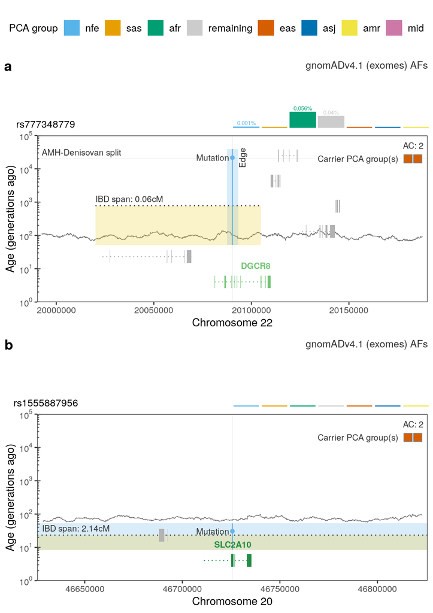

```r
eas_vus_doubletons_plot <- ggarrange(
  plot_legend,
  ggarrange(example1_plot, example2_plot, ncol = 1, labels = c("a", "b")),
  ncol = 1,
  heights = c(0.1, 1)
)
eas_vus_doubletons_plot
```

Save to PDF

```r
ggsave(paste0(paths$plots_dir, "vus_eas_example.pdf"), eas_vus_doubletons_plot, width = 6, height = 8.5)
```